# Evaluating the Role of Airbnb in Zurich’s Neighbourhoods

Ana Mas Urquijo, Azeglio Martinelli

2026-02-20

# 1 Introduction

Zurich is widely recognised as one of the most constrained housing markets in Switzerland. Strong population growth, limited land availability, and a persistently low vacancy rate have made access to long-term rental housing increasingly difficult. For many residents, the process of finding an apartment involves long waiting lists and crowded viewings, reflecting the intense competition for available housing. Ensuring sufficient long-term housing supply has therefore become a key policy challenge for the city.

At the same time, short-term rental platforms such as Airbnb have expanded significantly in Zurich over the past decade. These platforms offer flexible accommodation options for tourists and business travellers and can provide additional income opportunities for residents. However, when residential units are offered frequently or on a year-round basis as short-term rentals, they may reduce the availability of housing for long-term residents. This potential trade-off between tourism demand and housing supply has sparked increasing public debate.

In response to similar challenges, several Swiss cities and cantons have introduced regulatory measures aimed at limiting the intensity of short-term rentals. One commonly discussed instrument is a cap on the number of nights per year that a dwelling may be rented to tourists, such as a limit of 90 nights annually. The City of Zurich is currently considering whether comparable regulations would be appropriate and how such measures could be implemented in a targeted and proportionate way.

Importantly, the role of Airbnb is unlikely to be uniform across the city. In some neighbourhoods, short-term rentals may complement existing accommodation infrastructure, particularly where hotel capacity is limited. In other areas, a high concentration of listings or hosts managing multiple properties may indicate a more commercial use of residential housing. At the same time, guest reviews and booking activity provide insight into whether Airbnb listings deliver positive experiences for visitors, which is a relevant consideration for tourism policy.

This analysis is conducted for a hypothetical client, the City of Zurich, with the objective of evaluating the role of Airbnb across Zurich neighbourhoods. Using publicly available data, the study examines spatial and temporal patterns of Airbnb listings analyzing room_type, prices, type of hosts, reviews, minimum stays and availability to assess if Airbnbs should somehow be limited in Zurich or in certain areas.

## 1.1 Objectives and Research Questions

The objective of this study is to support the City of Zurich in evaluating whether, and where, regulatory measures on short-term Airbnb rentals may be appropriate.

The analysis addresses:

**RQ1:** How are Airbnb listings distributed across Zurich neighbourhoods, and which areas show the highest concentration?

**RQ2:** In which neighbourhoods does Airbnb complement existing hotel infrastructure, and where might it compete with hotels or reduce long-term housing availability?

**RQ3:** To what extent is Airbnb activity driven by hosts offering multiple listings, indicating more commercial use of residential properties?

**RQ4:** Which neighbourhoods exhibit high short-term rental intensity, as reflected by availability and minimum stay requirements?

**RQ5:** Do guest reviews indicate positive tourist experiences, and does this vary across neighbourhoods or host types?

**RQ6:** Based on listing concentration, host behaviour, rental intensity, and pricing patterns, which neighbourhoods would be most affected by potential regulatory measures?

# 2 Dataset

## 2.1 Data Sources

The analysis is based on publicly available data from **Inside Airbnb** (https://insideairbnb.com/get-the-data/), an independent, non-commercial project that provides detailed information on Airbnb listings in cities around the world. The platform compiles data directly from Airbnb’s website and aims to support research and policy discussions around short-term rentals.

Two datasets for the city of Zurich are used in this study:

1. **Listings dataset** This dataset contains detailed information on individual Airbnb listings, including their location, room type, price, availability, minimum stay requirements, and host characteristics. It also includes variables such as the number of listings per host and whether a listing is associated with a license.
2. **Reviews dataset** This dataset contains information on guest reviews, including review dates and the number of reviews over time. It allows for an assessment of demand dynamics and guest experiences across listings and neighbourhoods.

The two datasets are merged using the unique listing identifier. This combined dataset enables a joint analysis of spatial distribution, host behaviour, usage intensity, and guest feedback. All data preparation steps, including cleaning and merging, are documented and highlighted in the analysis to ensure full reproducibility.

## 2.2 Data Preparation and Transformations

### 2.2.1 Importing and Inspecting the data

**Unpacking**: The cell below was run only once to unpack the reviews data from a .gz compressed folder. The code cell unpacked the data and directly deleted the compressed files.

```r
library(R.utils)
gunzip("../Data/reviews.csv.gz")
```

First, the listings and reviews datasets are imported from CSV files using read_csv and stored as d.listings and d.reviews. Let us import the csvs and get an overview of how the datasets look like to get a first impression. For this we start importing and using the glimpse function of the dplyr package as the head and str functions of base R do not make it that clean.

```r
d.listings <- read_csv("../Data/listings.csv")
glimpse(d.listings)
```

```
## Rows: 3,417
## Columns: 18
## $ id                             <dbl> 73282, 143821, 178448, 227039, 283737, …
## $ name                           <chr> "Clean, central, quiet", "LOFT on 2 flo…
## $ host_id                        <dbl> 377532, 697307, 854016, 1184427, 147777…
## $ host_name                      <chr> "Simona", "Erhan", "Delphine", "Lucas",…
## $ neighbourhood_group            <chr> "Kreis 3", "Kreis 3", "Kreis 2", "Kreis…
## $ neighbourhood                  <chr> "Sihlfeld", "Alt-Wiedikon", "Enge", "Es…
## $ latitude                       <dbl> 47.37167, 47.35761, 47.36514, 47.38942,…
## $ longitude                      <dbl> 8.519480, 8.521310, 8.526150, 8.518810,…
## $ room_type                      <chr> "Entire home/apt", "Entire home/apt", "…
## $ price                          <dbl> NA, 232, 48, 501, 160, NA, 360, 238, 22…
## $ minimum_nights                 <dbl> 1125, 3, 5, 4, 4, 5, 7, 5, 5, 3, 3, 3, …
## $ number_of_reviews              <dbl> 47, 0, 9, 31, 383, 11, 13, 7, 162, 25, …
## $ last_review                    <date> 2019-04-27, NA, 2016-05-10, 2023-08-22…
## $ reviews_per_month              <dbl> 0.29, NA, 0.05, 0.18, 2.30, 0.12, 0.08,…
## $ calculated_host_listings_count <dbl> 1, 1, 1, 1, 3, 1, 1, 1, 2, 5, 5, 5, 1, …
## $ availability_365               <dbl> 358, 269, 92, 280, 13, 0, 28, 232, 311,…
## $ number_of_reviews_ltm          <dbl> 0, 0, 0, 0, 21, 0, 0, 0, 15, 0, 0, 0, 2…
## $ license                        <lgl> NA, NA, NA, NA, NA, NA, NA, NA, NA, NA,…
```

**Data Type Transformations**

The first impression tells us, that the license columnn might completely be empty. Furthermore, we see that we have:

- dbl: Double types, which are numeric values with decimals for continuous numbers.
- chr: Character type, which are text values (strings).
- date: Date type, which is stored in a specific date format.
- lgl: Logical type, storing TRUE or FALSE values

We convert the variables room_type, neighbourhood, and neighbourhood_group to factors because they represent categorical rather than numerical information. This ensures they are treated as discrete groups in the analysis and allows the model to estimate category-specific effects appropriately.

The variables id and host_id are converted to character because they serve as unique identifiers and do not carry numerical meaning.

**Missing Data**

After converting the required types, the amount of missing data is examined by:

- calculating the absolute number of missing values in each column
- visualizing the proportion of missing values relative to the total number of observations
- visualizing the missing patterns to understand if missing data is systematic.

This provides an overview of data completeness and helps identify variables that may require cleaning or removal.

```r
# Convert ids to characters and neighbourhoods and roomtype to factors
d.listings <- d.listings %>%
  mutate(
    id = as.character(id),
    host_id = as.character(host_id),
    neighbourhood_group = factor(neighbourhood_group),
    room_type = factor(room_type),
    neighbourhood = factor(neighbourhood)
  )

# missing data in each column
d.listings %>%
  summarise(across(everything(), ~ sum(is.na(.x)))) %>%
  pivot_longer(everything(),
               names_to = "variable",
               values_to = "n_missing") %>%
  filter(n_missing > 0) %>%          # keeps only variables with missing values
  arrange(desc(n_missing))
```

```
## # A tibble: 4 × 2
##   variable          n_missing
##   <chr>                 <int>
## 1 license                3417
## 2 last_review             834
## 3 reviews_per_month       834
## 4 price                   825
```

Based on this inspection, the column license will be removed from the listings dataset, as our assumption that it only contained missing values was correct. For reviews_per_month and last_review the same amount of observations are missing, which makes us assume, that these will probably be from the same Airbnbs, that probably never had a review at all. The missing price is also close to the reviews missing. But lets look at how much % these missing observations actually are:

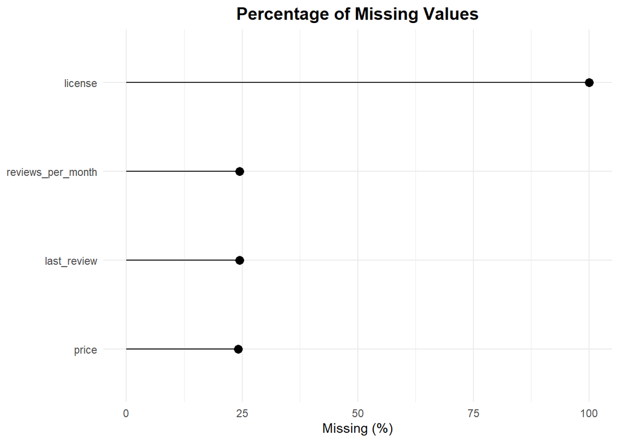

```r
# Compute percentage of missing values per variable
d.listings %>%
  summarise(across(everything(), ~ mean(is.na(.x)))) %>% # Share of NA values for each column
  pivot_longer(everything(),
               names_to = "variable",
               values_to = "pct_missing") %>%
  mutate(pct_missing = pct_missing * 100) %>% # Convert proportion to percentage
  filter(pct_missing > 0) %>%  # Keep only variables with missing values
  ggplot(aes(x = pct_missing,
             y = reorder(variable, pct_missing))) +
  geom_segment(aes(x = 0, xend = pct_missing, # Draw horizontal line from 0 to % missing
                   yend = variable)) +
  geom_point(size = 3) + # Add point at end of each line
  labs(
    title = "Percentage of Missing Values",
    x = "Missing (%)",
    y = NULL
  ) +
  theme_minimal() +
  theme(
    plot.title = element_text(
      hjust = 0.5,
      face  = "bold",
      size  = 14
    )
  )
```

The percentages are quite notable, for the 3 almost 25%. But are the observations of price missing the same as for the other 2? Let’s check for this the missing pattern visualization and also to see, if the data is missing systematically.

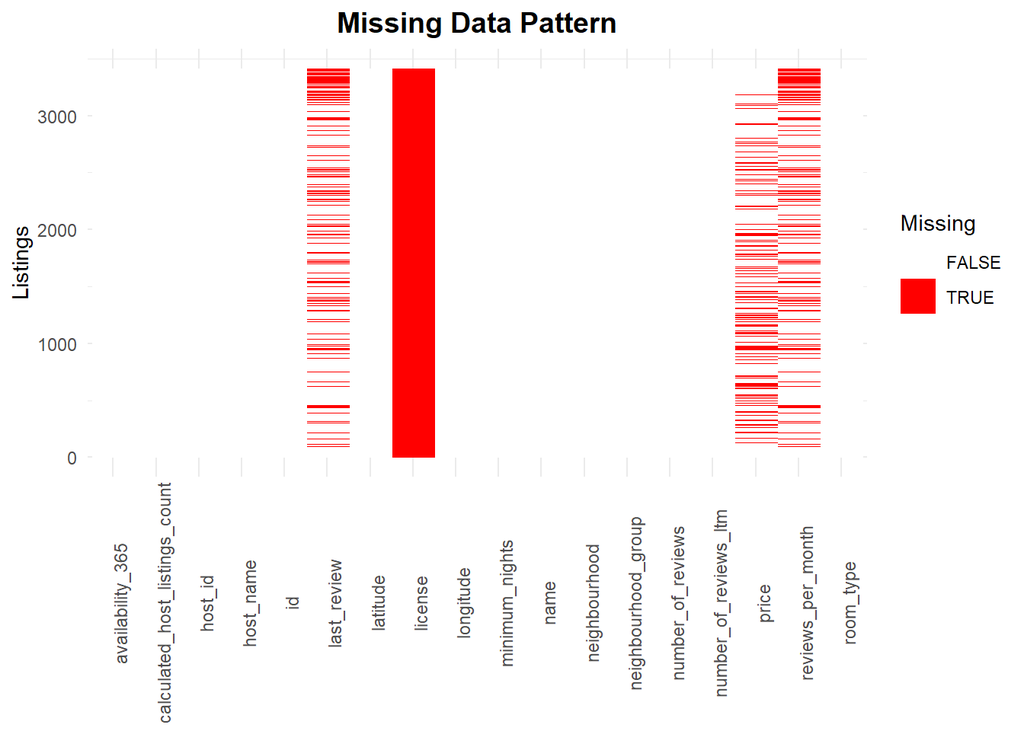

```r
d.listings %>%
  mutate(row_id = row_number()) %>% # Create a row identifier for plotting
  pivot_longer(
    -row_id,
    names_to = "variable",
    values_to = "value",
    values_transform = list(value = as.character)   # Convert all values to character for consistent reshaping
  ) %>%
  mutate(is_missing = is.na(value)) %>% # Flag whether each cell is missing
  ggplot(aes(x = variable, y = row_id, fill = is_missing)) +
  geom_raster() +                       # Draw a tile for each cell in the dataset
  scale_fill_manual(values = c("FALSE" = "white",
                               "TRUE"  = "red")) +
  labs(
    title = "Missing Data Pattern",
    x = NULL,
    y = "Listings",
    fill = "Missing"
  ) +
  theme_minimal() +
  theme(
    axis.text.x = element_text(angle = 90),
    plot.title  = element_text(
      hjust = 0.5,
      face  = "bold",
      size  = 14
    )
  )
```

The visualization clearly shows, that the missing price observations are mostly not the same Airbnbs as the ones that did not have reviews.

While we will replace the missing values of reviews per month variables with zero, we will delete all the Airbnbs with price 0, as throughout the analysis, the price is one of the most important aspects and furthermore the fact of not having a price probably means that the Airbnb was actually either not available, not on rent at the moment or the web scraper was not able to scrape the price. The last_review variable is intentionally left unchanged, as imputing a date where none exists would not be meaningful.

Finally, the listings dataset is checked for duplicate listing identifiers. This is done by counting how often each id appears, filtering for those that occur more than once, and displaying only the distinct duplicated entries. This step verifies whether the primary key in the listings data is unique, which is important for reliable joins and further analysis.

There are no duplicate listing identifiers. Now let us import and inspect the reviews.csv.

```r
d.reviews <- read_csv("../Data/reviews.csv")
glimpse(d.reviews)
```

```
## Rows: 109,592
## Columns: 6
## $ listing_id    <dbl> 73282, 73282, 73282, 73282, 73282, 73282, 73282, 73282, …
## $ id            <dbl> 1304820, 1448861, 1574534, 1745571, 2026650, 2185724, 22…
## $ date          <date> 2012-05-19, 2012-06-10, 2012-06-27, 2012-07-19, 2012-08…
## $ reviewer_id   <dbl> 1787723, 2183393, 2343568, 2343192, 2092762, 3386921, 39…
## $ reviewer_name <chr> "Jeff", "Rick", "Joseph", "Yvonne", "Joy", "Petru", "Mar…
## $ comments      <chr> "Simona was an excellent hostess. The apartment is beaut…
```

First, the ids are also converted from double to character and we check for missing values.

There are only 4 missing values in the comments column, these are replaced with the string “Unknown” so that all review records contain a valid text entry and can be processed consistently. Afterwards, all non-English comments are deleted, which represent 28.2% of the total comments. It is explained in the next section why this was done.

After cleaning the 2 datasets separately, we can continue to merged them.

First, a join condition is explicitly defined to link the two datasets by matching the id column in the listings data with the listing_id column in the reviews data. Using this condition, the cleaned listings dataset is merged with the reviews dataset using a left join, ensuring that all listings are retained in the merged dataset while review information is added where a matching review exists.

After performing the merge, sanity checks are carried out to assess whether the join behaved as expected. The total number of rows in the merged dataset is computed and compared with the number of rows in the listings data. In addition, the number of unmatched rows is calculated by counting how many entries have missing values in the review identifier column, indicating listings for which no corresponding review record was found.

```r
by <- join_by(id == listing_id)

d.merged <- d.listings %>%
  left_join(d.reviews_eng, by = by)

# Sanity checks for merge below

# Check number of matches where join columns of reviews are NA
d.merged %>%
  summarise(
    total = n(),
    unmatched = sum(is.na(id.y))
  )
```

```
## # A tibble: 1 × 2
##   total unmatched
##   <int>     <int>
## 1 70062       719
```

Finally, to improve clarity and avoid ambiguity in the merged dataset, review-related columns are renamed. The review identifier column originating from the reviews table is renamed to review_id, and the review date column is renamed to review_date, making the structure and meaning of the merged data clearer for subsequent analysis.

```r
# anti_join to inspect any mismatches
unmatched <- anti_join(d.listings, d.reviews, by = c("id" = "listing_id"))
glimpse(unmatched)
```

```
## Rows: 624
## Columns: 17
## $ id                             <chr> "143821", "1738497", "4666089", "537850…
## $ name                           <chr> "LOFT on 2 floors in Sihlcity Zürich", …
## $ host_id                        <chr> "697307", "9155256", "2598633", "181283…
## $ host_name                      <chr> "Erhan", "Marcin Jakub", "Antonio", "Al…
## $ neighbourhood_group            <fct> Kreis 3, Kreis 4, Kreis 5, Kreis 11, Kr…
## $ neighbourhood                  <fct> Alt-Wiedikon, Langstrasse, Gewerbeschul…
## $ latitude                       <dbl> 47.35761, 47.38092, 47.38573, 47.41072,…
## $ longitude                      <dbl> 8.521310, 8.526628, 8.527430, 8.544790,…
## $ room_type                      <fct> Entire home/apt, Entire home/apt, Priva…
## $ price                          <dbl> 232, 87, 191, 57, 547, 107, 182, 280, 1…
## $ minimum_nights                 <dbl> 3, 7, 1, 7, 3, 1, 95, 180, 30, 3, 1, 36…
## $ number_of_reviews              <dbl> 0, 0, 0, 0, 0, 0, 0, 0, 0, 0, 0, 0, 0, …
## $ last_review                    <date> NA, NA, NA, NA, NA, NA, NA, NA, NA, NA…
## $ reviews_per_month              <dbl> 0, 0, 0, 0, 0, 0, 0, 0, 0, 0, 0, 0, 0, …
## $ calculated_host_listings_count <dbl> 1, 1, 1, 1, 1, 98, 1, 1, 1, 3, 98, 1, 1…
## $ availability_365               <dbl> 269, 271, 88, 86, 365, 60, 363, 365, 59…
## $ number_of_reviews_ltm          <dbl> 0, 0, 0, 0, 0, 0, 0, 0, 0, 0, 0, 0, 0, …
```

```r
# rename different review columns
d.merged <- d.merged %>%
  rename(review_id = id.y, review_date = date)
```

### 2.2.2 Chapter of choice / Sentiment Analysis

For the chapter of choice, a Sentiment Analysis on the comment is done to augment the merged dataset with a sentiment score. This is the reason why all non-English comments were deleted in the Data Preparation section because the Sentiment Analysis employed can only handle English text and all non-English text is assigned with negative scores even if the comment itself is very positive.

First, we start by creating a reduced data frame that contains only the review identifier and the associated review text. Then, the following text preprocessing steps are done on this comments data frame. All comments are converted to lowercase to ensure that words differing only by capitalization are treated as the same token during analysis. After that, all punctuation is removed so that it does no interfere with word matching in the sentiment lexicon.

With the preprocessing done, the comments are tokenized. Meaning each comment is first split into individiual words, with one word per row, to allow for easier analysis of the data frame. Of course, review_id is kept to later aggregate back to comment level.

The Bing sentiment lexicon is then loaded. With this lexicon, the tokenized words are catgorized in a binary fashion, either positive or negative. The tokenized words are joined with this lexicon so that only words appearing in the sentiment dictionary are retained and assigned a corresponding sentiment. Next, the sentiment information is aggregated at the comment level. The categorization of each word is safed into one of two columns, either ‘n_positive’ or ‘n_negative’, as counts. These counts are then assigned a score of 1 if the comment contains more positive than negative words, -1 for the opposite case and 0 if the numbers are equal, indicating a neutral comment.

Lastly, the sentiment score columns are merged with the original ‘d.merged’ dataset on the review identifier using a left join. Any reviews that did not contain words found in the bing lexicon are assigned a neutral score of 0. This is done so that the score column contains no empty values. The result is the original dataset being augmented with a sentiment score for each review that reflects its overall tone and can be used for visualizations.

Let us have a look as how our merged dataset is looking now.

```r
# this is here just so that the cell can be re-run without duplicating the new columns
d.merged <- d.merged %>%
  select(c(id:comments))

comments_df <- d.merged %>%
  select(review_id, comments)

# Preprocess data; important for effective sentiment analysis

# Lowercase
comments_df <- comments_df %>%
  mutate(comments = tolower(comments))

# Remove punctuation
comments_df <- comments_df %>%
  mutate(comments = gsub("[[:punct:]]", "", comments))

# Tokenize into one word per row; review_id is kept automatically
text_words <- comments_df %>%
  unnest_tokens(word, comments)

bing <- get_sentiments("bing")

sentiment_bing <- text_words %>%
  inner_join(bing, by = "word")

# if a comment exceeds treshold he will be categorized as either good, neutral or bad
# it depends on the number of positive and negative words/sentiments in the comment
sentiment_per_comment_bing <- sentiment_bing %>%
  group_by(review_id) %>%
  summarise(
    n_positive = sum(sentiment == "positive"),
    n_negative = sum(sentiment == "negative"),
    .groups = "drop"
  ) %>%
  mutate(
    bing_score = case_when(
      n_positive > n_negative ~  1,   # good
      n_positive < n_negative ~ -1,   # bad
      TRUE                    ~  0    # neutral
    )
  )

d.merged <- d.merged %>%
  left_join(sentiment_per_comment_bing, by = "review_id") %>%
  mutate(
    bing_score = if_else(is.na(bing_score), 0L, bing_score)
  )
glimpse(d.merged)
```

```
## Rows: 70,062
## Columns: 25
## $ id                             <chr> "143821", "178448", "178448", "178448",…
## $ name                           <chr> "LOFT on 2 floors in Sihlcity Zürich", …
## $ host_id                        <chr> "697307", "854016", "854016", "854016",…
## $ host_name                      <chr> "Erhan", "Delphine", "Delphine", "Delph…
## $ neighbourhood_group            <fct> Kreis 3, Kreis 2, Kreis 2, Kreis 2, Kre…
## $ neighbourhood                  <fct> Alt-Wiedikon, Enge, Enge, Enge, Enge, E…
## $ latitude                       <dbl> 47.35761, 47.36514, 47.36514, 47.36514,…
## $ longitude                      <dbl> 8.52131, 8.52615, 8.52615, 8.52615, 8.5…
## $ room_type                      <fct> Entire home/apt, Private room, Private …
## $ price                          <dbl> 232, 48, 48, 48, 48, 48, 48, 48, 501, 5…
## $ minimum_nights                 <dbl> 3, 5, 5, 5, 5, 5, 5, 5, 4, 4, 4, 4, 4, …
## $ number_of_reviews              <dbl> 0, 9, 9, 9, 9, 9, 9, 9, 31, 31, 31, 31,…
## $ last_review                    <date> NA, 2016-05-10, 2016-05-10, 2016-05-10…
## $ reviews_per_month              <dbl> 0.00, 0.05, 0.05, 0.05, 0.05, 0.05, 0.0…
## $ calculated_host_listings_count <dbl> 1, 1, 1, 1, 1, 1, 1, 1, 1, 1, 1, 1, 1, …
## $ availability_365               <dbl> 269, 92, 92, 92, 92, 92, 92, 92, 280, 2…
## $ number_of_reviews_ltm          <dbl> 0, 0, 0, 0, 0, 0, 0, 0, 0, 0, 0, 0, 0, …
## $ review_id                      <chr> NA, "487704", "498140", "518094", "6752…
## $ review_date                    <date> NA, 2011-08-30, 2011-09-03, 2011-09-10…
## $ reviewer_id                    <chr> NA, "178448", "178448", "178448", "1784…
## $ reviewer_name                  <chr> NA, "Brian", "Joshua", "Melanie", "Sara…
## $ comments                       <chr> NA, "Stellar host!  five stars and then…
## $ n_positive                     <int> NA, 9, 8, 4, 8, 8, 8, 5, 7, 14, 7, 9, 6…
## $ n_negative                     <int> NA, 0, 1, 0, 0, 0, 0, 1, 1, 6, 0, 0, 0,…
## $ bing_score                     <dbl> 0, 1, 1, 1, 1, 1, 1, 1, 1, 1, 1, 1, 1, …
```

While we have now the bing_score per comment, it will be interesting to have also a final dataset that shows the mean bing_score per Airbnb and the number of reviews, in order to kind of create a mean rating of each of the Airbnbs and also see if this is trustworthy depending on the number of reviews (if just one review, it is not that representative).

```r
# Compute listing-level sentiment measures from review data
listing_sentiment <- d.merged %>%
  group_by(id) %>%
  summarise(
    mean_bing_score = mean(bing_score[!is.na(review_id)], na.rm = TRUE), # Average sentiment per listing
    n_english_reviews = sum(!is.na(review_id)),  # Count of English reviews
    .groups = "drop"
  )

# Merge back
d.listings_with_sentiment <- d.listings %>%
  left_join(listing_sentiment, by = "id")

glimpse(d.listings_with_sentiment)
```

```
## Rows: 2,592
## Columns: 19
## $ id                             <chr> "143821", "178448", "227039", "283737",…
## $ name                           <chr> "LOFT on 2 floors in Sihlcity Zürich", …
## $ host_id                        <chr> "697307", "854016", "1184427", "1477771…
## $ host_name                      <chr> "Erhan", "Delphine", "Lucas", "Nuria", …
## $ neighbourhood_group            <fct> Kreis 3, Kreis 2, Kreis 5, Kreis 1, Kre…
## $ neighbourhood                  <fct> Alt-Wiedikon, Enge, Escher Wyss, Rathau…
## $ latitude                       <dbl> 47.35761, 47.36514, 47.38942, 47.37372,…
## $ longitude                      <dbl> 8.521310, 8.526150, 8.518810, 8.544520,…
## $ room_type                      <fct> Entire home/apt, Private room, Entire h…
## $ price                          <dbl> 232, 48, 501, 160, 360, 238, 227, 185, …
## $ minimum_nights                 <dbl> 3, 5, 4, 4, 7, 5, 5, 3, 3, 3, 2, 1, 2, …
## $ number_of_reviews              <dbl> 0, 9, 31, 383, 13, 7, 162, 25, 8, 12, 1…
## $ last_review                    <date> NA, 2016-05-10, 2023-08-22, 2025-09-08…
## $ reviews_per_month              <dbl> 0.00, 0.05, 0.18, 2.30, 0.08, 0.04, 1.0…
## $ calculated_host_listings_count <dbl> 1, 1, 1, 3, 1, 1, 2, 5, 5, 5, 1, 1, 1, …
## $ availability_365               <dbl> 269, 92, 280, 13, 28, 232, 311, 357, 24…
## $ number_of_reviews_ltm          <dbl> 0, 0, 0, 21, 0, 0, 15, 0, 0, 0, 2, 0, 5…
## $ mean_bing_score                <dbl> NaN, 1.0000000, 1.0000000, 0.8666667, 1…
## $ n_english_reviews              <int> 0, 7, 30, 315, 12, 7, 123, 23, 5, 9, 55…
```

This d.merged dataset and also the d.listings_with_sentiment dataset, where the average “rating” per Airbnb is included, provide a solid basis for the analysis. The next chapter dives into the data’s characteristics, patterns and trends.

## 2.3 Summary Statistics of data

To gain an initial understanding of the dataset, descriptive summary statistics are computed for all relevant numeric variables. These statistics provide an overview of central tendency (mean, median), dispersion (standard deviation), and distribution (minimum, quartiles, maximum), allowing us to better understand the structure and variability of the data before proceeding to more advanced analyses. We are excluding the numeric variables latitude, longitude, n_negative, n_positive as these are not meaningful for the descriptive statitsics.

```r
# These variables are numeric but are identifiers, coordinates,
# or sentiment counters that are not meaningful for descriptive stats
vars_exclude <- c(
  "latitude",
  "longitude",
  "n_negative",
  "n_positive")


# Create a summary table for the remaining numeric variables
num_summary <- d.merged %>%

  # Keep only numeric variables and remove unwanted ones
  # This ensures we compute statistics only on meaningful quantities
  select(
    where(is.numeric),
    -any_of(vars_exclude)
  ) %>%

  # Compute multiple summary statistics for each numeric variable
  summarise(
    across(
      everything(),

      # List of summary functions to apply to EACH variable
      list(
        # Number of non-missing observations
        n      = ~sum(!is.na(.)),

        # Central tendency
        mean   = ~mean(., na.rm = TRUE),
        median = ~median(., na.rm = TRUE),

        # Dispersion
        sd     = ~sd(., na.rm = TRUE),

        # Distribution shape
        min    = ~min(., na.rm = TRUE),
        q25    = ~quantile(., 0.25, na.rm = TRUE),
        q75    = ~quantile(., 0.75, na.rm = TRUE),
        max    = ~max(., na.rm = TRUE)
      ),

      # Naming convention: variable__statistic
      # This allows us to later split the column name into:
      # - variable name
      # - statistic name
      .names = "{.col}__{.fn}"
    )
  ) %>%

  # Reshape from wide to long format
  # We now have three columns: variable, stat, and value
  pivot_longer(
    everything(),
    names_to  = c("variable", "stat"),
    names_sep = "__",   # must match the separator used above
    values_to = "value"
  ) %>%

  # Reshape back to a clean summary table
  # Now we have one row per variable
  # and each statistic is its own column again
  pivot_wider(
    names_from  = stat,
    values_from = value
  ) %>%

  # Order rows alphabetically to guide the reader
  arrange(variable) %>%

  # Round numeric results to 2 decimals (except n)
  mutate(
    across(-c(variable, n), ~round(.,2))
  )

num_summary
```

```
## # A tibble: 8 × 9
##   variable                       n   mean median     sd   min   q25   q75    max
##   <chr>                      <dbl>  <dbl>  <dbl>  <dbl> <dbl> <dbl> <dbl>  <dbl>
## 1 availability_365           70062 172.   158    126.       0 53    300   3.65e2
## 2 bing_score                 70062   0.93   1      0.3     -1  1      1   1   e0
## 3 calculated_host_listings_… 70062  27.1    4     43.8      1  1     19   1.79e2
## 4 minimum_nights             70062   2.59   2      5.77     1  1      2   3.65e2
## 5 number_of_reviews          70062 235.   155    252.       0 62    321   1.38e3
## 6 number_of_reviews_ltm      70062  37.7   28     34.1      0 13     55   1.61e2
## 7 price                      70062 169.   136    154.      10 98    193   1   e4
## 8 reviews_per_month          70062   3.3    2.81   2.51     0  1.32   4.7 1.54e1
```

Furthermore, some boxplots are visualized to show the distrubution these variables are following.

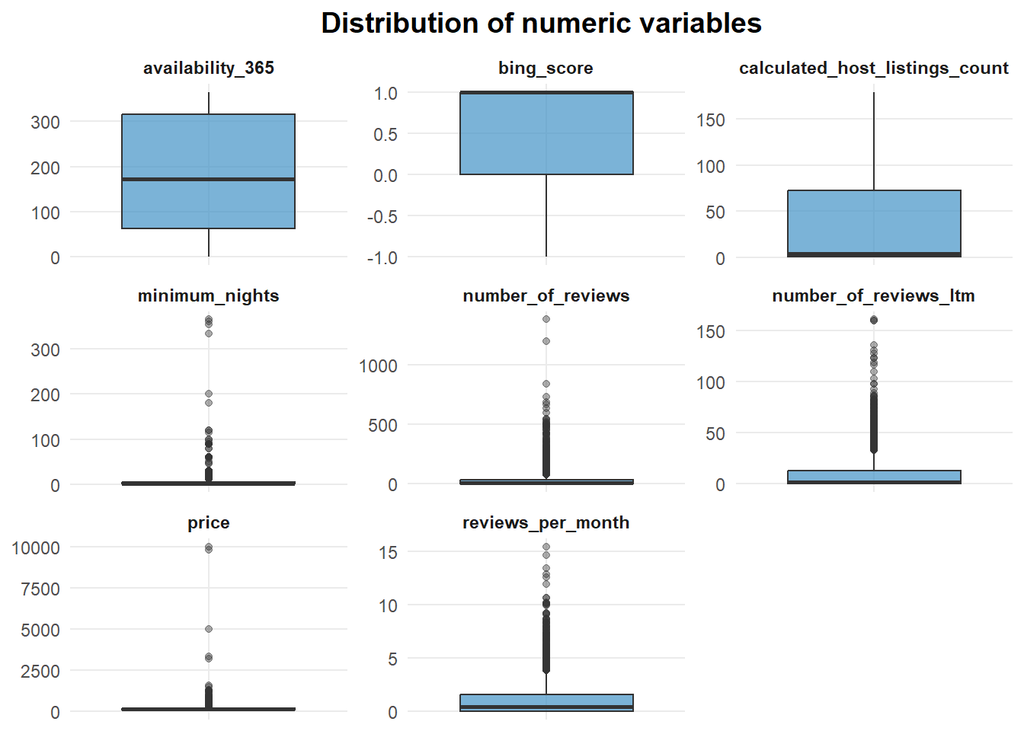

```r
# Prepare data for boxplots:
# Keep one row per id, select relevant numeric variables,
# and reshape to long format for plotting
boxplot_data <- d.merged %>%
  distinct(id, .keep_all = TRUE) %>%
  select(
    where(is.numeric),
    -any_of(vars_exclude)
  ) %>%
  pivot_longer(
    everything(),
    names_to  = "variable",
    values_to = "value"
  )

# Create faceted boxplots to show the distribution,
# of each numeric variable separately
ggplot(boxplot_data, aes(x = "", y = value)) +
  geom_boxplot(
    fill  = "#4292c6",
    alpha = 0.7,
    outlier.alpha = 0.4
  ) +
  facet_wrap(
    ~ variable,
    scales = "free_y"
  ) +
  labs(
    title = "Distribution of numeric variables",
    x = NULL,
    y = NULL
  ) +
  theme_minimal() +
theme(
  strip.text = element_text(face = "bold"),
  axis.text.x = element_blank(),
  axis.ticks.x = element_blank(),
  panel.grid.minor = element_blank(),
  plot.title = element_text(hjust = 0.5, face = "bold", size = 14)
)
```

The summary statistics reveal substantial heterogeneity across listings. Prices are right-skewed, with a mean (168.63) above the median (136), indicating the presence of high-priced listings. A similar right-skewed pattern appears for review counts and host listing counts, suggesting that while most listings and hosts operate at moderate levels, a small number are highly active. In particular, the high values of calculated_host_listings_count indicate that some hosts manage many properties, which likely reflects professional operators or companies rather than individual hosts.

Minimum nights is generally low (median = 2), but extreme values exist, reflecting some listings with strict booking requirements. Availability varies considerably across listings, indicating differences in how intensively properties are offered.

The sentiment score is strongly concentrated at positive values (median = 1), confirming that most reviews are favorable.

Although several variables exhibit extreme values, these appear economically plausible and are therefore retained in the analysis.

## 2.4 Correlation Analysis and multicollinearity

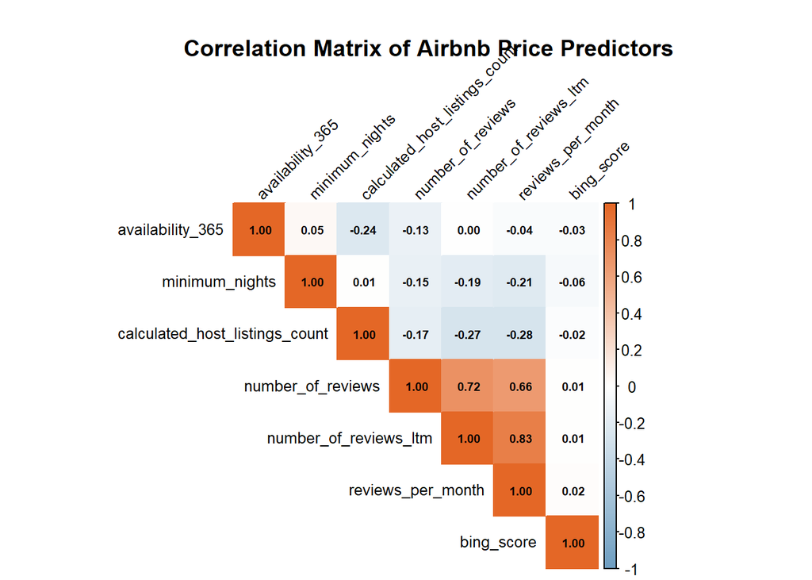

```r
# Select relevant numeric variables for the correlation analysis
# Numeric data (exclude coords + intermediate sentiment counts)
airbnb_numeric <- d.merged %>%
  select(
    price,
    availability_365,
    minimum_nights,
    calculated_host_listings_count,
    number_of_reviews,
    number_of_reviews_ltm,
    reviews_per_month,
    bing_score
  )

# Correlations (default method is 'pearson')
cor_predictors <- cor(airbnb_numeric %>% select(-price), use = "complete.obs")

# Choosing colour
my_cols <- colorRampPalette(c("#6D9EC1", "white", "#E46726"))(200)

corrplot(
  cor_predictors,
  method       = "color",  # Use colored squares to show correlation strength
  type         = "upper",  # Display only the upper triangle of the matrix
  tl.col       = "black",  # Text label color
  tl.srt       = 45,       # Rotate variable labels for readability
  tl.cex       = 0.8,      # Label text size
  addCoef.col  = "black",  # Print correlation coefficients in each cell
  number.cex   = 0.6,      # Size of coefficient text
  col          = my_cols,
  cl.lim       = c(-1, 1), # Fix color scale from -1 to 1
  mar          = c(0, 0, 2, 0)
)

title(
  main = "Correlation Matrix of Airbnb Price Predictors",
  font.main = 2,   # bold
  cex.main  = 1.2  # larger size
)
```

To assess the relationships among the main numeric predictors, a correlation matrix using Pearson’s method was computed. Overall, most variables exhibit weak pairwise correlations, suggesting limited concerns regarding multicollinearity. In particular, availability, minimum nights, host listing count, and sentiment score show only small correlations with other predictors.

However, strong positive correlations are observed among the review-related variables. The total number of reviews, the number of reviews in the last twelve months, and reviews per month are highly correlated, indicating that these variables capture a similar underlying dimension of listing popularity. Including all of them simultaneously in a regression model could therefore introduce multicollinearity and inflate standard errors. For this reason, only a the variable total number of reviews will be included in the linear model done later.

Overall, aside from the review-related measures, the correlation matrix suggests that the explanatory variables are largely independent, supporting the robustness of the regression analysis.

# 3 Data Anaylsis through Visualizations

To answer the research questions, the data are systematically analysed in this chapter. We present a series of visualisations to highlight key patterns and insights, and we discuss their implications for the City of Zurich. All analyses are based either on the merged dataset described in the previous chapter or in some cases on the listings_with_sentiment dataset.

For most visualizations, temporary working datasets are created. This approach ensures that the original dataset remains unchanged and transparent, while allowing targeted data transformations tailored to each specific analysis.

## 3.1 Number of listings per room type

**What type of accomodation is Airbnb offering?**

A first step in understanding the Airbnb market in Zurich is to examine what type of accommodation is predominantly offered.

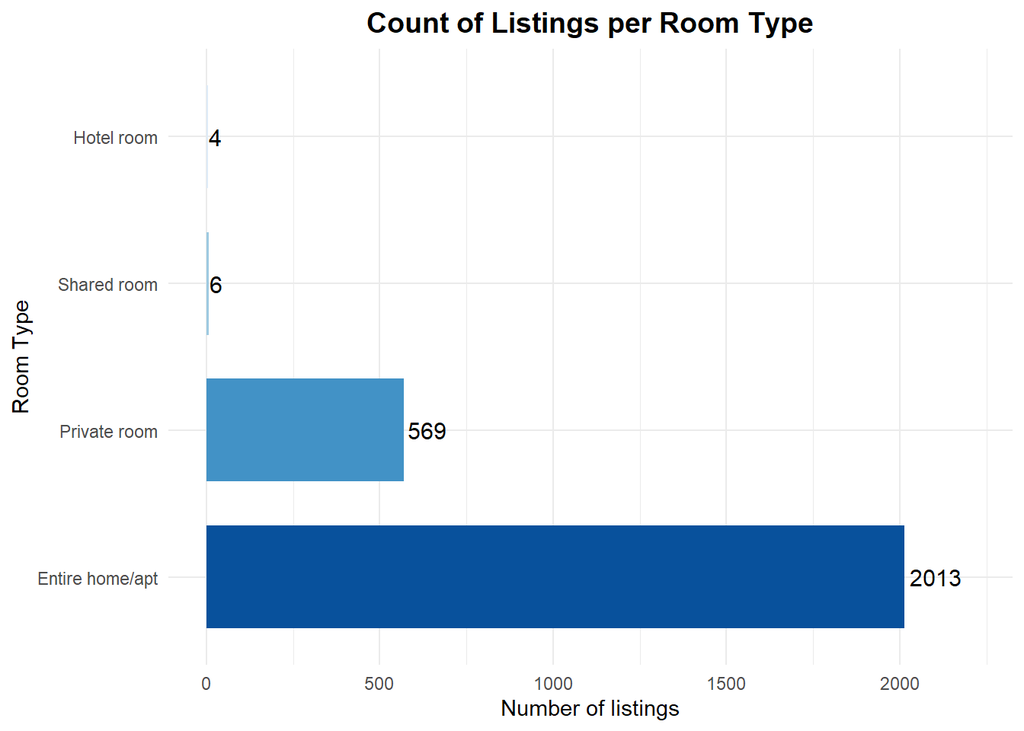

```r
# Listing-level counts per room type
room_counts <- d.merged %>%
  distinct(id, room_type) %>%
  count(room_type, name = "value") %>%
  mutate(
    room_type = factor(
      room_type,
      levels = c(
        "Entire home/apt",
        "Private room",
        "Shared room",
        "Hotel room"
      )
    )
  )

# Horizontal bar chart
ggplot(
  room_counts,
  aes(
    x    = value,
    y    = room_type,
    fill = room_type
  )
) +
  geom_col(width = 0.7) +
  geom_text(
    aes(label = value),
    hjust = -0.1,
    size = 4
  ) +
  # choose colours of types
  scale_fill_manual(
    values = c(
      "Entire home/apt" = "#08519c",
      "Private room"    = "#4292c6",
      "Shared room"     = "#9ecae1",
      "Hotel room"      = "#deebf7"
    ),
    guide = "none"
  ) +
  labs(
    title = "Count of Listings per Room Type",
    x = "Number of listings",
    y = "Room Type"
  ) +
  expand_limits(x = max(room_counts$value) * 1.1) +
  theme_minimal() +
  theme(
    plot.title = element_text(hjust = 0.5, face = "bold", size = 14)
  )
```

The visualisation shows that the majority of listings are rented as entire homes or apartments, followed by private rooms. Shared rooms and hotel rooms account for only a very small fraction of total listings. Private and shared room rentals — where guests stay within a dwelling that is also occupied by the host — make up roughly one quarter of the market. In these cases, Airbnb may serve as a supplementary source of income for residents, for example to help cover Zurich’s relatively high housing costs or to monetise unused space during certain periods of the year.

In contrast, approximately three quarters of listings consist of entire apartments. These listings may reflect different use cases. Some may be operated by professional or semi-professional hosts managing multiple properties. Others may belong to individual residents who temporarily rent out their full apartment while travelling, for example during holidays. However, unlike private room rentals, entire-home listings involve complete residential units and may therefore have a more direct impact on the availability of long-term housing.

This distinction between spare-room rentals and full-apartment rentals is central when assessing the potential housing market implications for the City of Zurich.

## 3.2 Listings per host

**Who is renting out the Airbnbs?**

After understanding what types of accommodation are offered, the next important question is who is supplying them. In particular, it is relevant for the City of Zurich to assess whether the market is mainly driven by individual residents renting out one property or by hosts operating multiple listings in a more commercial manner.

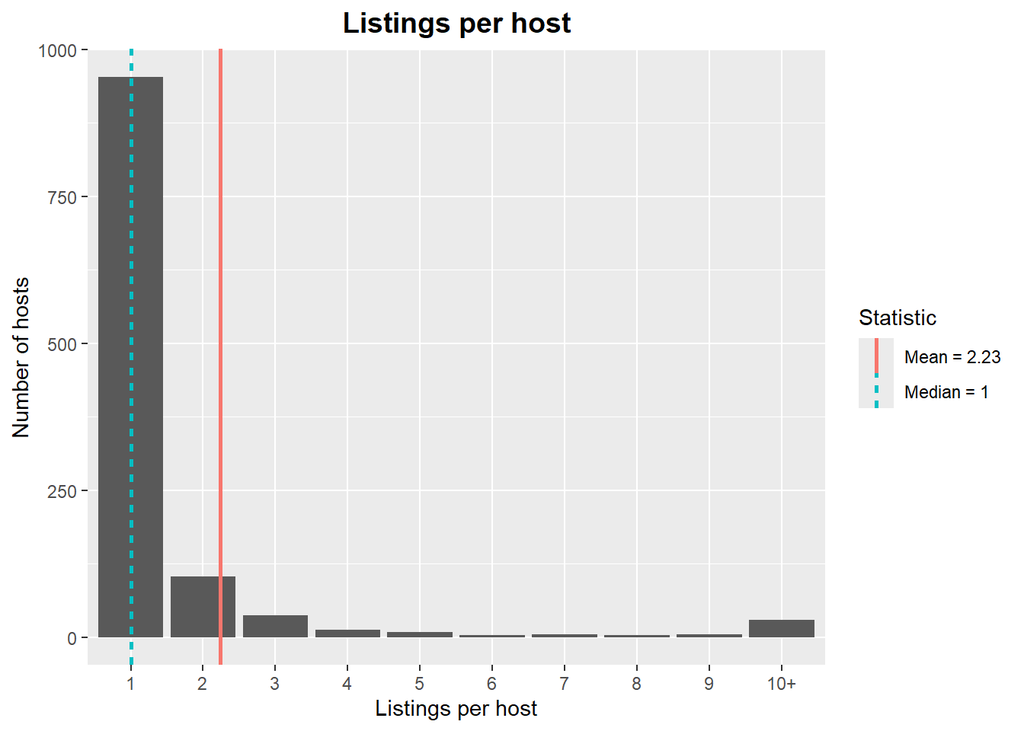

```r
# Compute the number of listings per host
listings_per_host <- d.merged %>%
  distinct(host_id, id) %>%                    # Keep one row per listing per host
  count(host_id, name = "listings_per_host")   # Count listings per host

# Group hosts with 10 or more listings
listings_per_host <- listings_per_host %>%
  mutate(listings_group =
           ifelse(
             listings_per_host >= 10,           # Condition: 10+ listings
             "10+",                             # Group them as "10+"
             as.character(listings_per_host)    # Otherwise keep exact number
           ))

# Convert grouped variable into a factor to order on the x-axis
listings_per_host <- listings_per_host %>%
  mutate(listings_group = factor(
    listings_group,
    levels = c(as.character(1:9), "10+")        # Ensure "10+" appears at the end
  ))


# Create mean and median lines and legend
stats_lines <- data.frame(
  statistic = c(
    paste0("Mean = ", round(mean(listings_per_host$listings_per_host), 2)),
    paste0("Median = ", median(listings_per_host$listings_per_host))
  ),
  value = c(
    mean(listings_per_host$listings_per_host),
    median(listings_per_host$listings_per_host)
  )
)

# Bar chart
ggplot(listings_per_host, aes(x = listings_group)) +
  geom_bar() +

  # Draw mean and median lines
  geom_vline(data = stats_lines,
             aes(xintercept = value,
                 color = statistic,
                 linetype = statistic),
             linewidth = 1) +

  labs(title = "Listings per host",
       x = "Listings per host",
       y = "Number of hosts",
       color = "Statistic",
       linetype = "Statistic") +

  theme(plot.title = element_text(hjust = 0.5, face = "bold", size = 14))
```

The distribution of listings per host is highly right-skewed. The median host operates a single listing, while the mean of 2.23 listings per host reflects the presence of a smaller group of multi-listing hosts. This indicates that the Airbnb market is primarily composed of individual hosts, although a minority of more professional hosts contributes disproportionately to total supply.

### 3.2.1 Distribution of minimum nights

**For how long do guests usually stay?**

The histogram illustrates the distribution of minimum stay requirements for Airbnb listings across Zurich. The analysis is based on listing-level data and focuses on values between 1 and 35 nights.

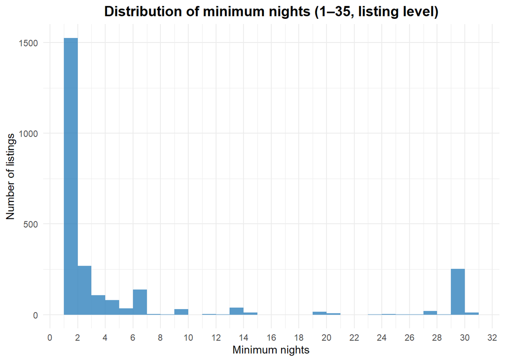

```r
# Keep one row per listing (unique id) to ensure
# each listing is counted only once
interim <- d.merged %>%
  distinct(id, .keep_all = TRUE)

# Create a histogram of minimum nights
# to show how listing requirements are distributed
ggplot(
  interim %>% filter(minimum_nights <= 35), # Restrict to 35 or fewer
  aes(x = minimum_nights)
) +
  geom_histogram(
    binwidth = 1,        # Width of each bin (1 unit per bar)
    fill = "#3182bd",  # Bar color
    alpha = 0.8,         # Transparency level
    boundary = 0         # Align bins to start at 0
  ) +
  # Set x-axis ticks from 0 to 35 in steps of 2
  scale_x_continuous(breaks = seq(0, 35, 2)) +
  labs(
    title = "Distribution of minimum nights (1–35, listing level)",
    x = "Minimum nights",
    y = "Number of listings"
  ) +
  theme_minimal() +
  theme(
    plot.title = element_text(
      hjust = 0.5,
      face  = "bold",
      size  = 14
    )
  )
```

The distribution is strongly right-skewed. The vast majority of listings require a minimum stay of only 1 or 2 nights. This indicates that short-term visits are the predominant form of accommodation on the platform. From a housing policy perspective, this may suggest that many listings are primarily targeting tourists or short business stays rather than medium- or long-term tenants. However, minimum stay alone does not fully determine rental intensity, and additional indicators are needed to assess potential housing market impacts.

The frequency declines rapidly up to around 7 minimum nights. Beyond that point, only a small number of listings require longer stays. Nevertheless, there are some visible spikes in the right tail — for example at 20 nights and, more notably, at 30 nights. The concentration at 30 nights may reflect strategic behaviour, such as aligning with monthly rental cycles or adapting to regulatory thresholds observed in other cities.

Overall, the distribution reveals a dominant short-term rental segment characterised by very low minimum stay requirements, alongside a smaller but clearly present group of listings targeting longer stays.

### 3.2.2 Minimum nights per neighbourhood map

**Are there spatial differences?**

The visual below deepens our knowledge of the previous insights regarding minimum nights per stay. It displays the mean minimum nights of all listings per neighbourhood as a bubble map. The bigger the bubble the higher the minimum nights mean value.

```r
# Load unique listings
listings <- d.merged %>%
  distinct(id, .keep_all = TRUE)

# Mean minimum_nights per neighbourhood
neigh_stats <- listings %>%
  group_by(neighbourhood) %>%
  summarise(
    mean_minimum_nights = mean(minimum_nights, na.rm = TRUE),
    n_listings         = n(),
    .groups = "drop"
  )

# Join to neighbourhood polygons and transform to WGS84 (lat/lon)
geo_min <- geojson %>%
  left_join(neigh_stats, by = "neighbourhood")

# Transform coordinates to WGS84 (required for leaflet maps)
geo_min_4326 <- st_transform(geo_min, 4326)

# Point per neighbourhood (for bubbles)
neigh_pts <- st_point_on_surface(geo_min_4326)
coords    <- st_coordinates(neigh_pts)

# Extract longitude and latitude into a regular data frame
pts_df <- cbind(
  st_drop_geometry(neigh_pts),
  lon = coords[, "X"],
  lat = coords[, "Y"]
)

# Define colour palette and scale bubble sizes by mean minimum nights
pal <- colorNumeric("cividis", domain = pts_df$mean_minimum_nights)
radius_scaled <- rescale(pts_df$mean_minimum_nights, to = c(4, 16))

# Interactive leaflet map with neighbourhood borders and bubbles
leaflet(geo_min_4326) %>%
  addProviderTiles(providers$OpenStreetMap.Mapnik) %>%

  addControl(
      html = "<h3 style='margin:5px; font-weight:bold;'>
              Mean Minimum Nights by Neighbourhood
              </h3>",
      position = "topright"
    ) %>%

  # Neighbourhood outlines
  addPolygons(
    color         = "#444444",   # border colour
    weight        = 1.2,           # thickness of line
    opacity       = 0.9,
    fill          = FALSE,         # just outlines
    highlightOptions = highlightOptions(
      color = "red",
      weight = 2,
      bringToFront = TRUE
    ),
    label = ~neighbourhood         # hover label on polygons
  ) %>%

  # Add one bubble per neighbourhood
  addCircleMarkers(
    data        = pts_df,
    lng         = ~lon,
    lat         = ~lat,
    radius      = radius_scaled,
    color       = "#ffffff",     # White border around bubbles
    weight      = 1,
    fillColor   = ~pal(mean_minimum_nights), # Fill color based on mean minimum nights
    fillOpacity = 0.85,
    popup = ~paste0(
      "<b>", neighbourhood, "</b><br>",
      "Mean minimum nights: ", round(mean_minimum_nights, 1), "<br>",
      "Listings: ", n_listings
    )
  ) %>%

  addLegend(
    pal      = pal,
    values   = ~mean_minimum_nights,
    position = "bottomright",
    title    = "Mean minimum nights"
  )
```

[interactive chart not shown]

Most neighbourhoods have relatively low mean minimum stays, typically between 1 and 19 nights. Central areas, particularly around the Old Town, tend to show lower minimum stay requirements, suggesting a stronger focus on short-term visitors such as tourists and business travellers.

Saatlen stands out with a notably higher average minimum stay. However, this neighbourhood has only a small number of listings, which likely drives this result and limits its broader interpretability.

Overall, the map confirms that short-term rental intensity varies across Zurich, with central neighbourhoods appearing more strongly oriented toward very short stays.

## 3.3 Airbnbs and hotels per neighbourhood 2025

**What areas are mostly covered by hotels and where do Airbnbs complement well?**

To better understand Airbnb’s role within Zurich’s overall accommodation landscape, it is important to assess how its spatial distribution compares to that of traditional hotels. This helps clarify whether Airbnb primarily complements existing infrastructure or competes directly with it.

```r
# Check if hotels data already exists
# Otherwise, download it from OpenStreetMap and save it for future use
if (file.exists("../Data/osm_hotels_zurich.rds")) {
  osm_hotels <- readRDS("../Data/osm_hotels_zurich.rds")
} else {

  # Get hotels from OpenStreetMap
  osm_hotels <- opq("Zurich, Switzerland", timeout = 500) %>%
    add_osm_feature(key = "tourism", value = "hotel") %>%
    osmdata_sf()

  # Save hotels data
  saveRDS(osm_hotels, "../Data/osm_hotels_zurich.rds")
}

# Keep hotel polygons and convert each polygon to 1 point
# (leaflet works more easily with points for markers)
hotels <- st_point_on_surface(osm_hotels$osm_polygons)

# Keep only Airbnb listings from 2025 and ensure one row per listing
airbnb_2025 <- d.merged %>%
  filter(year(review_date) == 2025) %>%
  distinct(id, .keep_all = TRUE)

# Simple interactive map with neighbourhoods and hotels
leaflet() %>%
  addTiles() %>% # Base map

  addControl(
      html = "
        <div style='text-align:center; width:100%;'>
          <h3 style='margin:8px; font-weight:bold;'>
            Airbnbs and Hotels per Neighbourhood (2025)
          </h3>
          <div style='font-size:13px;'>
            Spatial comparison of traditional hotels and Airbnb listings
          </div>
        </div>
      ",
      position = "topright"
    ) %>%

  # Add neighbourhood boundaries
  addPolygons(
    data = geojson,
    weight = 2,
    fill = 1
  ) %>%
  # Add hotels as small black dots
  addCircleMarkers(
    data = hotels,
    radius = 2,
    fillOpacity = 1,
    color = "black"
  ) %>%
  # Add Airbnb listings (2025) as red dots
  addCircleMarkers(
    data = airbnb_2025,
    lng = ~longitude,
    lat = ~latitude,
    radius = 2,
    stroke = FALSE,
    fillOpacity = 1,
    color = "red"
  )
```

[interactive chart not shown]

The map displays the geographic distribution of Airbnb listings (red points) and hotels (black points) across the city. A clear pattern emerges: Airbnb listings are highly concentrated in central districts, particularly in and around the city centre, where demand for short-term accommodation is strongest.

Hotels are also mainly located in central and well-connected areas. However, their distribution appears more concentrated and less dense. In several outer neighbourhoods, Airbnb listings are present despite the absence of nearby hotels.

This spatial difference suggests a dual role. In peripheral areas with limited hotel infrastructure, Airbnb may expand accommodation capacity and improve geographic coverage for visitors. In contrast, in central districts where both hotels and Airbnb listings cluster, Airbnb is more likely to act as a direct competitor and may contribute to higher tourism intensity.

For the City of Zurich, this spatial differentiation is particularly relevant. It enables a more targeted assessment of where Airbnb strengthens the accommodation offer and where it may increase tourism pressure or housing market strain, supporting evidence-based regulatory and urban planning decisions.

## 3.4 Evolution of number of Airbnb listings

**Is Airbnb growing?**

To assess how the relevance of Airbnb has evolved over time, it is important to examine the development of listing numbers in Zurich. The following figure illustrates the annual growth in Airbnb listings and provides insight into how strongly the platform has expanded within the city’s accommodation market.

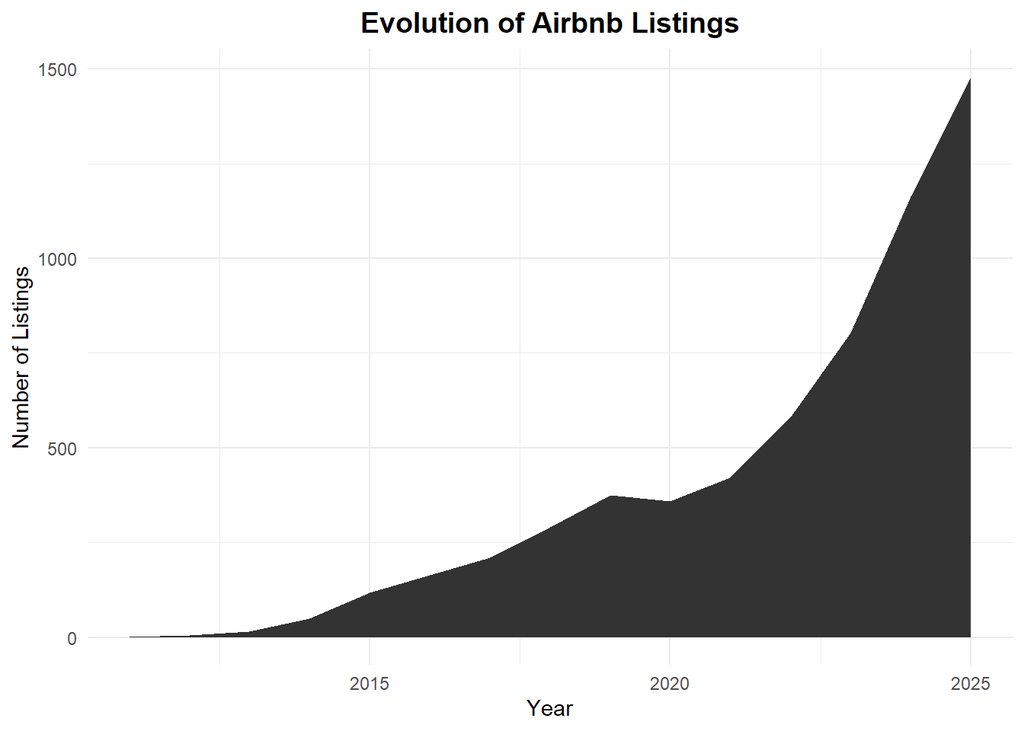

```r
# Count the number of unique listings per year
listings_per_year <- d.merged %>%
  filter(!is.na(review_date)) %>%
  mutate(year = year(review_date)) %>% # Extract year from the review date
  group_by(year) %>%
  summarise(n_listings = n_distinct(id))

# Plot the development of listings over time using an area chart
ggplot(listings_per_year, aes(x = year, y = n_listings)) +
  geom_area() +
  labs(
    title = "Evolution of Airbnb Listings",
    x = "Year",
    y = "Number of Listings"
  ) +
  theme_minimal() +
  theme(
    plot.title = element_text(hjust = 0.5, face = "bold", size = 14)
  )
```

The figure shows a strong upward trend in the number of Airbnb listings in Zurich over time. After gradual growth in the early years, listings increased steadily until 2019. Around 2020, growth temporarily slowed, likely due to the COVID-19 pandemic. From 2021 onward, the number of listings rose sharply, reaching approximately 1,500 by 2025. Overall, the trend indicates that Airbnb has become an increasingly important part of Zurich’s accommodation market.

## 3.5 Evolution of reviews

**How happy are guests with Airbnbs and how have the ratings evolved over time?**

Not only the Airbnb listings, also the reviews evolution is important to analyze, in order to see how happy guests are and if this is improving or getting worse with the time.

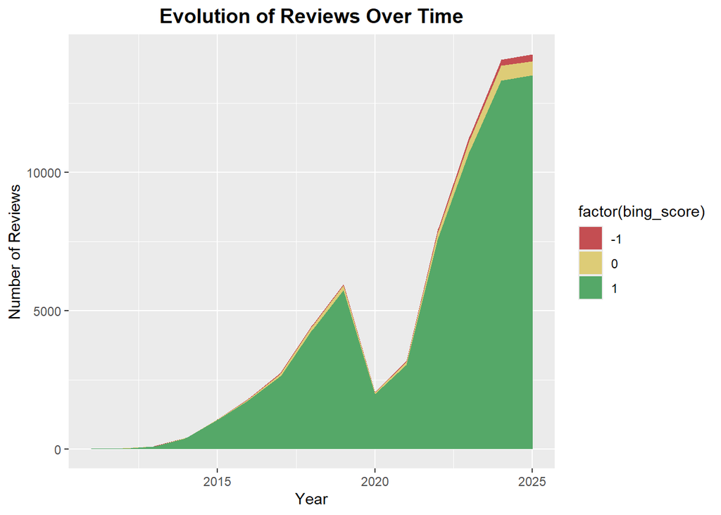

```r
# Count the number of reviews per year and sentiment category (bing_score)
reviews_year <- d.merged %>%
  filter(!is.na(review_date)) %>%      # Keep only rows with a review date
  mutate(year = year(review_date)) %>% # Extract year from review date
  group_by(year, bing_score) %>%
  summarise(number_of_reviews = n(), .groups = "drop")

# Plot how review volume evolves over time by sentiment
ggplot(reviews_year,
       aes(x = year, y = number_of_reviews, fill = factor(bing_score))) +
  geom_area() +                    # Stacked area chart
  scale_fill_manual(               # Manually assign colors to sentiments
    values = c(
      "-1" = "#C44E52",  # muted red
      "0"  = "#DDCC77",  # soft mustard yellow
      "1"  = "#55A868"   # muted green
    )
  ) +
  labs(
    title = "Evolution of Reviews Over Time",
    x = "Year",
    y = "Number of Reviews"
  ) +
  theme(
    plot.title = element_text(hjust = 0.5, face = "bold", size = 14)
  )
```

The figure shows a strong increase in the total number of Airbnb reviews over time, closely mirroring the growth in listings. Reviews rise steadily until 2019, decline sharply around 2020—likely due to the COVID-19 pandemic—and then increase rapidly again from 2021 onward.

The vast majority of reviews are positive (green), while neutral and negative reviews represent only a small share throughout the period. This indicates consistently high customer satisfaction despite the rapid expansion of the platform.

Overall, the trend suggests both growing market activity and persistently positive guest experiences over time.

## 3.6 Reviews analysis maps

**Do certain areas get in general better review?**

Below the two maps visualize negative reviews. The left map displays the absolute number of negative reviews, while the right map shows the proportion of negative reviews.

[figure not shown]

```r
# Count number of negative reviews per neighbourhood
neg_stats <- d.merged %>%
  filter(bing_score == -1) %>%     # Keep only negative reviews
  group_by(neighbourhood) %>%
  summarise(
    n_negative_reviews = n(),
    .groups = "drop"
  )

# Count total number of reviews per neighbourhood
all_stats <- d.merged %>%
  group_by(neighbourhood) %>%
  summarise(
    number_of_reviews = n(),
    .groups = "drop"
  )

# Combine both datasets and compute share of negative reviews
neg_stats <- neg_stats %>%
  left_join(all_stats, by = "neighbourhood") %>%
  mutate(
    share_negative = n_negative_reviews / number_of_reviews
  )

# Join review statistics to neighbourhood geometry
geo_neg <- geojson %>%
  left_join(neg_stats, by = "neighbourhood")

# Map 1: absolute number of negative reviews per neighbourhood
p_count <- ggplot(geo_neg) +
  geom_sf(aes(fill = n_negative_reviews), color = "white", linewidth = 0.2) +
  scale_fill_viridis_c(
    option = "cividis",
    na.value = "grey90",
    name = "Negative reviews"
  ) +
  labs(
    title = "Number of negative reviews per neighbourhood",
    subtitle = "Lighter areas have more negative reviews"
  ) +
  theme_minimal() +
  theme(
    plot.title = element_text(size = 11, face = "bold", hjust = 0.5),
    plot.subtitle = element_text(size = 10, hjust = 0.5),
    plot.margin = margin(5, 10, 5, 10)
  )

# Map 2: share of negative reviews
p_share <- ggplot(geo_neg) +
  geom_sf(aes(fill = share_negative), color = "white", linewidth = 0.2) +
  scale_fill_viridis_c(
    option = "cividis",
    na.value = "grey90",
    labels = scales::percent_format(accuracy = 1),
    name = "% negative"
  ) +
  labs(
    title = "Share of negative reviews per neighbourhood",
    subtitle = "Fraction of reviews with bing_score = -1"
  ) +
  theme_minimal() +
  theme(
    plot.title = element_text(size = 11, face = "bold", hjust = 0.5),
    plot.subtitle = element_text(size = 10, hjust = 0.5),
    plot.margin = margin(5, 10, 5, 10)
  )

# Combine both maps into one figure with a shared overall title
p_count + p_share +
  plot_annotation(
    title = "Negative Airbnb reviews in Zürich by neighbourhood",
    theme = theme(
      plot.title = element_text(
        face = "bold",
        size = 14,
        hjust = 0.5
      )
    )
  )
```

According to the left map, on first view one might believe that the city center receives by far the most negative reviews. But the city center is also the place with the most amount of stays and therefore the most reviews. Thus the proportion of negative reviews must be taken into account, which displays a more nuanced picture.

The city center is still one of the neighbourhoods with the highest percentage of negative reviews. Yet, there are much more neighbourhoods with a percentage above 2% and the neighbourhood Friesenberg even has a higher percentage than the city center.

Overall, the share of negative reviews is much more informative than the absolute number. Although there is spatial variation in the share of negative reviews, the absolute levels are low, with no neighbourhood exceeding approximately 2.5% negative feedback, suggesting generally high guest satisfaction citywide.

## 3.7 Mean price and number of stays per neighbourhood maps

**How do prices and stays vary across Zurich’s neighbourhoods?**

The visual below displays once the mean price and once the number of stays each per neighbourhood. The higher the value the lighter the coloring of the neighbourhood.

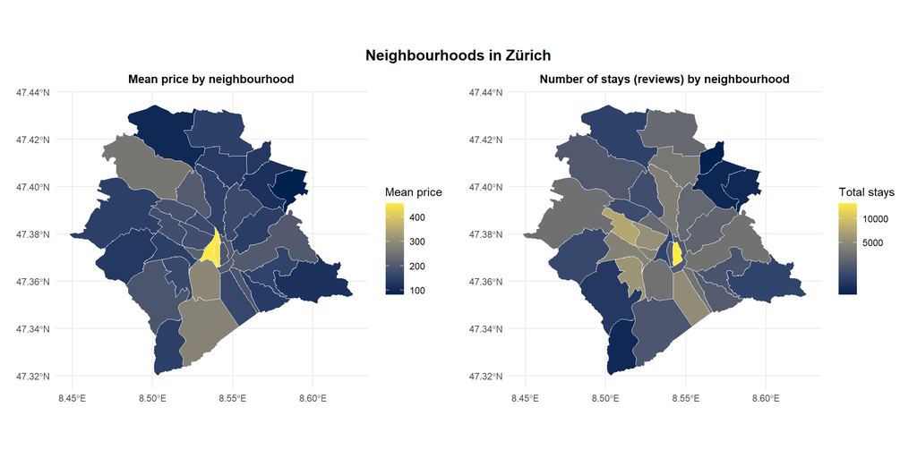

```r
listings <- d.merged %>%
  distinct(id, .keep_all = TRUE)

# Neighbourhood-level stats based on listings
map_stats <- listings %>%
  group_by(neighbourhood) %>%
  summarise(
    mean_price   = mean(price, na.rm = TRUE),
    total_stays  = sum(number_of_reviews, na.rm = TRUE),
    n_listings   = n(),
    .groups = "drop"
  )

# Join stats to neighbourhood geometries
geo_stats <- geojson %>%
  left_join(map_stats, by = "neighbourhood")

# Mean price map (neighbourhood)
p_price <- ggplot(geo_stats) +
  geom_sf(aes(fill = mean_price), color = "white", linewidth = 0.2) +
  scale_fill_viridis_c(option = "cividis") +
  labs(
    title = "Mean price by neighbourhood",
    fill  = "Mean price"
  ) +
  theme_minimal() +
  theme(
    plot.title   = element_text(size = 11, face = "bold", hjust = 0.5),
    plot.margin  = margin(5, 10, 5, 10)
  )

# Number of stays map (neighbourhood)
p_stays <- ggplot(geo_stats) +
  geom_sf(aes(fill = total_stays), color = "white", linewidth = 0.2) +
  scale_fill_viridis_c(option = "cividis", trans = "sqrt") +
  labs(
    title = "Number of stays (reviews) by neighbourhood",
    fill  = "Total stays"
  ) +
  theme_minimal() +
  theme(
    plot.title   = element_text(size = 11, face = "bold", hjust = 0.5),
    plot.margin  = margin(5, 10, 5, 10)
  )

# Combine plots
p_price + p_stays +
  plot_annotation(
    title = "Neighbourhoods in Zürich",
    theme = theme(
      plot.title = element_text(
        face = "bold",
        size = 14,
        hjust = 0.5
      )
    )
  )
```

The prices tend to be higher the closer the neighbourhood group is to the city center. This does not come as a surprise as most people want to minimize their time spent traveling to the city center for their stays. Therefore, listings close to the city center are desired and prices reflect this demand.

However, the number of stays per neighbourhoods reveals, that while the city center is the most popular according to number of stays, other neighbourhoods in close proximity also record a lot of bookings and are quite popular among guests.

## 3.8 Neighbourhood group characteristics

**How do neighbourhoods differ in their Airbnb characteristics?**

While the previous maps highlighted spatial differences in prices and booking activity, it is equally important to understand the structural characteristics of each neighbourhood group. The following comparison provides a broader profile of the Kreise in terms of host activity, listing concentration, pricing, and minimum stay requirements.

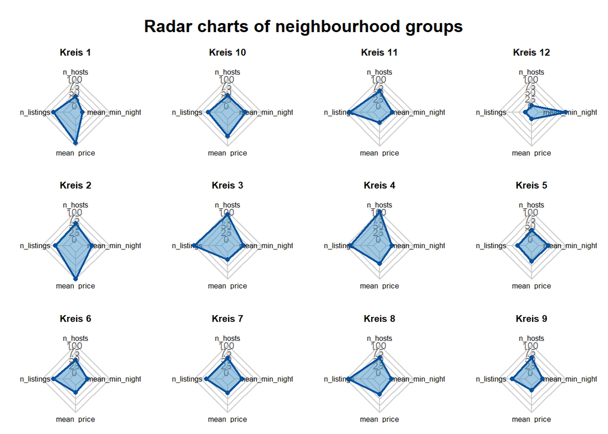

```r
listings <- d.merged %>%
  distinct(id, .keep_all = TRUE)

# Aggregate at neighbourhood_group level
radar_raw <- listings %>%
  group_by(neighbourhood_group) %>%
  summarise(
    n_hosts        = n_distinct(host_id),                  # unique hosts in the group
    n_listings     = n(),                                  # number of listings in this group
    mean_price      = mean(price, na.rm = TRUE),           # mean price
    mean_min_nights = mean(minimum_nights, na.rm = TRUE),  # mean minimum nights
    .groups = "drop"
  )

# Rescale all indicators to 0–100 so they can be compared on the same radar chart
radar_scaled <- radar_raw %>%
  mutate(
    n_hosts        = rescale(n_hosts,        to = c(0, 100)),
    n_listings     = rescale(n_listings,     to = c(0, 100)),
    mean_price      = rescale(mean_price,      to = c(0, 100)),
    mean_min_nights = rescale(mean_min_nights, to = c(0, 100))
  )

# Set up a 3 x 4 layout for 12 neighbourhood groups
par(
  mfrow = c(3, 4),
  mar   = c(1, 1, 3, 1),   # inner margins (per plot)
  oma   = c(0, 0, 3, 0)    # outer margin (top space for global title)
)

# Precompute global max and min for the axes (after scaling)
axis_max <- apply(radar_scaled[, -1], 2, max)
axis_min <- apply(radar_scaled[, -1], 2, min)

# Draw one radar chart per neighbourhood_group
for (g in radar_scaled$neighbourhood_group) {
  # pick one neighbourhood
  row_g <- radar_scaled %>%
    filter(neighbourhood_group == g) %>%
    select(n_hosts, n_listings, mean_price, mean_min_nights)

  # build the data frame: max row, min row, group row
  df_radar <- rbind(axis_max, axis_min, row_g)
  rownames(df_radar) <- c("max", "min", as.character(g))

  # Plot the radar chart with consistent styling across panels
  radarchart(
    df_radar,
    axistype = 1,
    pcol     = "#08519c",
    pfcol    = scales::alpha("#4292c6", 0.5),
    plwd     = 2,
    cglcol   = "grey80",
    cglty    = 1,
    axislabcol = "grey40",
    caxislabels = c("0", "25", "50", "75", "100"),
    vlcex    = 0.8
  )
  title(main = g, cex.main = 1)
}

mtext(
  "Radar charts of neighbourhood groups",
  outer = TRUE,
  cex   = 1.2,
  font  = 2
)
```

While we will not go into details of all neighbourhood groups, we will highlight some of them.

Kreis 1, the Old Town, displays higher prices, a moderate number of listings and hosts and shorter minimum stays. This is propably because of its smaller size and likely driven by tourists and business travelers looking for a premium market. Kreis 2 shows a similar profile.

Kreis 3 and 4 with the popular neighbourhood’s have profiles with the most hosts and listings indicating the most active market. Which might be also the most affected by possible changes to renting regulations.

# 4 Model - Price Prediction

## 4.1 Review vs Prices

**Do Airbnbs with more positive reviews tend to have higher prices?**

The figure shows the relationship between the number of reviews and log price, separated by review sentiment categories: negative (−1), neutral (0), and positive (1). Across all three groups, the relationship appears slightly negative, meaning that listings with more reviews tend to be marginally cheaper on average. One of the reasons could be, that probably cheaper places are rented more often, are easier to give away.

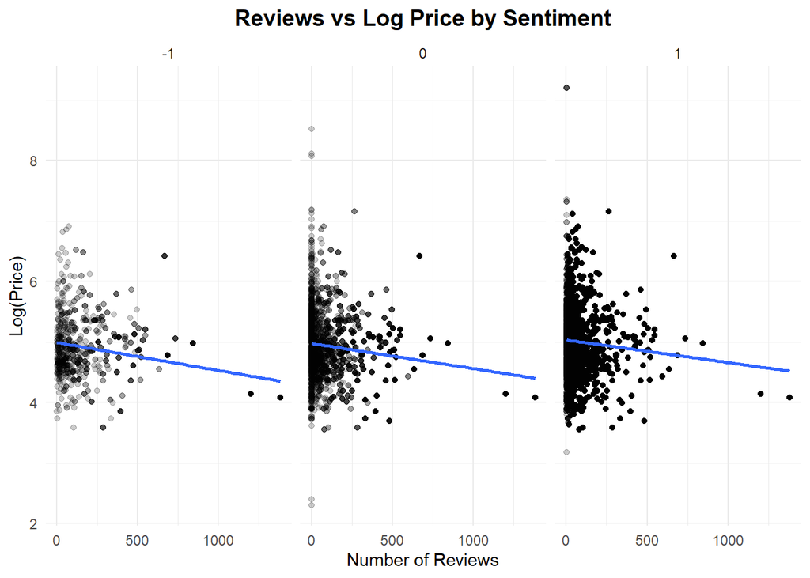

```r
# Same relationship, but split by sentiment category (bing_score)
# Shows whether the price–reviews relationship differs by review sentiment
ggplot(d.merged, aes(x = number_of_reviews, y = log(price))) +
  geom_point(alpha = 0.2) +
  geom_smooth(method = "lm", se = FALSE) +
  facet_wrap(~ factor(bing_score)) +     # One panel per sentiment category
  theme_minimal() +
  labs(
    title = "Reviews vs Log Price by Sentiment",
    x = "Number of Reviews",
    y = "Log(Price)"
  ) +
  theme(
    plot.title = element_text(
      hjust = 0.5,
      face  = "bold",
      size  = 14
    )
  )
```

While listings with positive sentiment generally exhibit somewhat higher overall price levels compared to neutral or negative listings, the slope of the relationship between review volume and price remains relatively similar across all sentiment categories. Overall, the number of reviews does not appear to be a strong visual driver of price differences.

## 4.2 Linear Model

**Which factors significantly determine Airbnb prices in Zurich?**

To formally assess which factors drive Airbnb prices in Zurich, we estimate a linear regression model using log(price) as the dependent variable. For the room type we have taken entire homes/ apartments and for neighbourhood the basis is the “City” neighbourhood.

```r
# Exponent for easier interpretation
round((exp(coef(lm_model)) - 1) * 100, 1)
```

```
##                       (Intercept)               room_typeHotel room
##                           31813.2                              49.7
##             room_typePrivate room              room_typeShared room
##                             -40.5                             -74.2
##            neighbourhoodAffoltern          neighbourhoodAlbisrieden
##                             -70.2                             -72.0
##         neighbourhoodAlt-Wiedikon           neighbourhoodAltstetten
##                             -66.7                             -65.7
##                 neighbourhoodEnge          neighbourhoodEscher Wyss
##                             -50.6                             -54.0
##             neighbourhoodFluntern          neighbourhoodFriesenberg
##                             -59.5                             -61.6
##        neighbourhoodGewerbeschule                 neighbourhoodHard
##                             -61.3                             -59.7
##           neighbourhoodHirslanden           neighbourhoodHirzenbach
##                             -59.7                             -76.1
##          neighbourhoodHochschulen                neighbourhoodHöngg
##                             -55.7                             -62.1
##            neighbourhoodHottingen          neighbourhoodLangstrasse
##                             -57.6                             -54.1
##             neighbourhoodLeimbach            neighbourhoodLindenhof
##                             -65.4                             -33.9
##            neighbourhoodMühlebach           neighbourhoodOberstrass
##                             -58.2                             -61.7
##             neighbourhoodOerlikon              neighbourhoodRathaus
##                             -65.8                             -56.5
##              neighbourhoodSaatlen neighbourhoodSchwamendingen-Mitte
##                             -75.3                             -73.2
##              neighbourhoodSeebach              neighbourhoodSeefeld
##                             -65.6                             -58.2
##             neighbourhoodSihlfeld          neighbourhoodUnterstrass
##                             -64.8                             -63.6
##              neighbourhoodWeinegg                 neighbourhoodWerd
##                             -67.2                             -52.1
##            neighbourhoodWipkingen              neighbourhoodWitikon
##                             -62.8                             -69.5
##          neighbourhoodWollishofen                   mean_bing_score
##                             -54.0                              17.4
##                 number_of_reviews    calculated_host_listings_count
##                               0.0                              -0.1
##                    minimum_nights                  availability_365
##                               0.0                               0.1
```

The model is statistically significant and explains about 28% of the variation in prices, which is typical for cross-sectional housing data. This indicates that key structural determinants are captured, although some price variation remains unexplained.

Review sentiment is positively associated with price, suggesting that listings with more positive review tone can charge higher prices. In contrast, the number of reviews, host portfolio size, and availability have statistically significant but economically small effects, while minimum nights shows no meaningful impact.

Overall, room type, neighbourhood, and sentiment emerge as the main determinants of Airbnb prices in Zurich.

## 4.3 Cross Validation

**What model does the best price predictions and should be used by Zurich City?**

We additionally evaluate the predictive performance of the models using 5-fold cross-validation. This step is different from the previous regression analysis: while the original linear model was estimated on the full dataset to interpret relationships and coefficients, cross-validation assesses how well the models perform on unseen data. In each fold, the model is trained on part of the data and tested on observations that were not used for estimation.

This way, the city of Zurich will be able to be sure, what the best model would be to predict the evolution of airbnb prices, which might be very useful.

In this case, we compare the original linear model (LM) with a polynomial version that includes nonlinear terms.

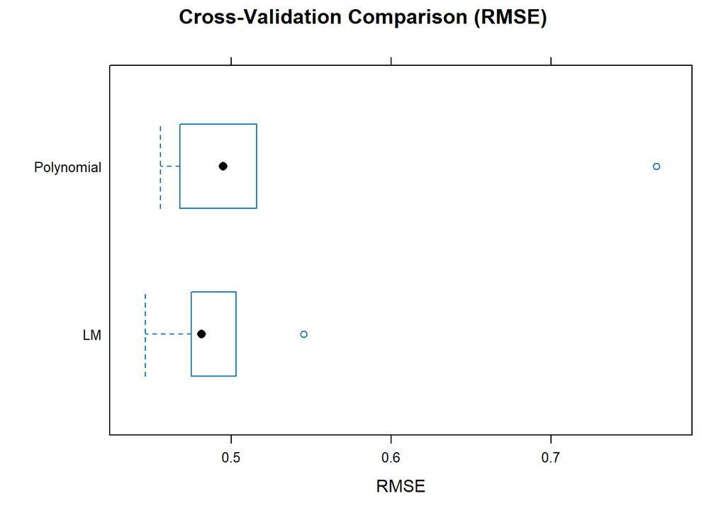

```r
bwplot(
  res,
  metric = "RMSE",
  main = list(
    label = "Cross-Validation Comparison (RMSE)",
    cex = 1.2,
    font = 2,
    just = c(0.5, 0.5) # Centering
  )
)
```

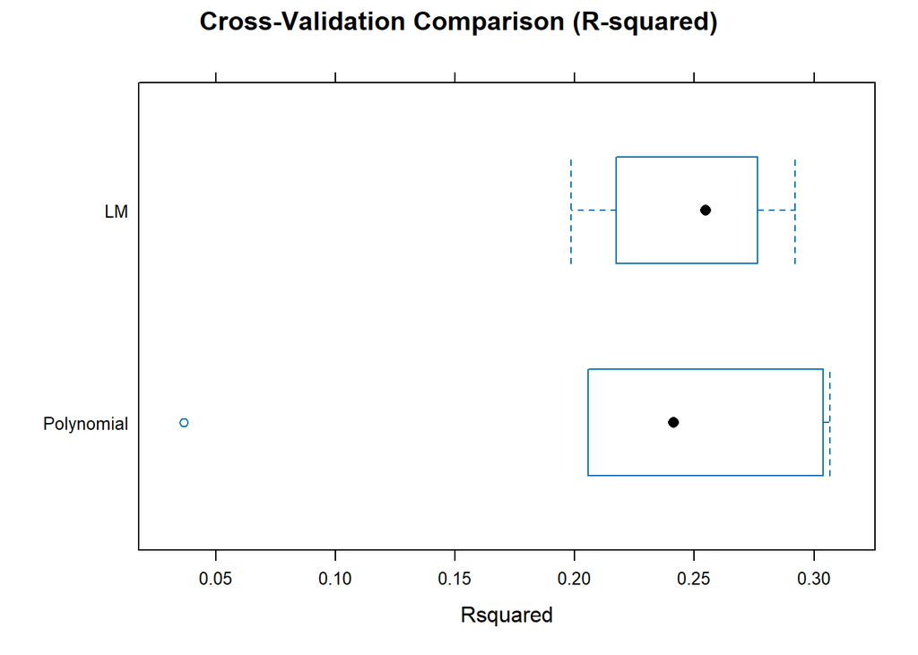

```r
bwplot(
  res,
  metric = "Rsquared",
  main = list(
    label = "Cross-Validation Comparison (R-squared)",
    cex = 1.2,
    font = 2,
    just = c(0.5, 0.5)
  )
)
```

In the first plot (RMSE), lower values indicate better predictive performance. The linear model has a slightly lower average RMSE than the polynomial model. This means that, when predicting unseen data, the linear model produces slightly smaller prediction errors in the prices.

In the second plot (R²), higher values indicate better explanatory power in the test folds. Again, the linear model shows a slightly higher average R² than the polynomial model. Thus, it explains slightly more of the variation in log prices in out-of-sample predictions.

The boxplots display the distribution of performance across the five folds. Both models perform relatively similarly, but the polynomial model shows somewhat more variability and does not deliver any consistent improvement.

Overall, there is no evidence that adding polynomial (nonlinear) terms improves predictive accuracy for unseen data. The simpler linear model performs at least as well — and slightly better — while being more stable and easier to interpret. Therefore, we can recommend the City of Zurich the linear model to predict the prices of Airbnbs in Zurich.

# 5 Conclusions

This analysis shows that Airbnb plays a differentiated role across Zurich’s neighbourhoods.

Listings are strongly concentrated in central districts, where prices are higher and rental intensity is strongest. In these areas, Airbnb is more likely to compete with hotels and may contribute to housing market pressure. In contrast, in peripheral neighbourhoods with limited hotel presence, Airbnb appears to complement the accommodation sector without the same degree of housing displacement risk.

The majority of hosts operate only one listing, suggesting that the market is largely driven by individuals. However, a smaller group of multi-listing hosts contributes disproportionately to supply, indicating commercial activity in specific areas.

Short minimum stay requirements and high availability confirm a strong short-term orientation, particularly in central neighbourhoods. Guest satisfaction is consistently high across the city, and more positive review sentiment is associated with higher prices.

Overall, the results indicate that Airbnb in Zurich is not a uniform phenomenon. Central neighbourhoods with high listing density and rental intensity would likely be most affected by regulatory measures. Therefore, targeted, neighbourhood-specific policies may be more appropriate than broad city-wide restrictions.

# 6 Potential Limitations

- **Static pricing information**: The dataset contains only one price per listing, although Airbnb prices are dynamic and may vary over time depending on demand, seasonality, and availability. Therefore, the observed price may not fully reflect actual pricing strategies throughout the year.
- **Limited property characteristics**: The dataset does not provide detailed information on property size, number of rooms, number of beds, capacity (number of guests), or number of bathrooms. These factors are likely important determinants of price and may lead to omitted variable bias in the regression analysis.
- **Simplified sentiment analysis**: Sentiment was measured using a basic lexicon-based approach (Bing dictionary). This method does not account for context, negation, or sarcasm. For example, phrases such as “not good” may be incorrectly classified as positive due to the presence of the word “good,” ignoring the negation.
- **Exclusion of non-English reviews**: Non-English comments were removed prior to sentiment analysis. As a result, reviews written in German, Swiss German, or other languages are not included, which may bias the sentiment measure and limit representativeness.

# 7 Use of GenAI

**What tools did we use?**

We mainly used ChatGPT and Gemini.

**What have you used it for?**

One of our main goals in this project was to use as little GenAI as possible in order to maximize our learning experience. We realized that in the previous semester we relied too heavily on such tools and did not achieve the learning progress we had hoped for.

Our main resources were the slides from the ILIAS Introduction to R course and the materials provided during the Bootcamp. Additionally, we created a dedicated project space within the GenAI tools to keep our work organized. We uploaded the course slides to these tools so that, whenever we had doubts or wanted to verify our approach, the responses would be aligned with the concepts covered in class.

GenAI was particularly helpful in explaining concepts that we did not fully understand. Rather than using it to generate complete solutions, we mainly used it as a supportive learning tool.

Another important use was improving the structure and clarity of our written analysis. We first drafted our ideas in our own English and then used GenAI to correct grammar, improve wording, and adjust the tone to better address our client.

**For what kind of tasks turned they out to be helpful?**

- Correcting language, grammar, and writing style
- Structuring and refining our analysis in a clearer and more professional way
- Supporting more advanced R functions or improving visual aspects of graphs (e.g., formatting or color adjustments)

**How do you check correctness of the answer?**

We verified the correctness of GenAI outputs primarily by running the suggested code and evaluating whether the results were reasonable. In addition, we compared explanations and approaches with the course slides and relevant cheat sheets.

**What did not work?**

Since we used GenAI selectively and always provided clear context and our own preliminary work, the tools generally worked well. We did not encounter major issues. However, we consistently evaluated the responses critically to ensure correctness and maintain academic integrity.